# Homework 6 - Market Basket Analysis

Nathan Heskia

### Dataset and Objective

The dataset consists of over 3 millions orders from [Instacart](https://www.kaggle.com/c/instacart-market-basket-analysis).

```r
library(rapportools)
library(arules)

# Load products file, which contains product id, department id and name
products <- read.csv('products.csv', sep = ",", stringsAsFactors = FALSE)

# Load orders, each row contains an order id and a product id. Since there
# are multiple rows per order, use format = `single`
instacartOrders <- read.transactions('order_products__prior.csv', format = 'single', header = TRUE, sep = ",", cols = c(1,2))

# Map product ids/labels in orders to readable name
itemLabels(instacartOrders) <- sapply(as.numeric(itemLabels(instacartOrders)), function(x) { products[which(products$product_id == x),]$product_name; })

summary(instacartOrders)
```

```
## transactions as itemMatrix in sparse format with
##  3214874 rows (elements/itemsets/transactions) and
##  49677 columns (items) and a density of 0.0002030896
##
## most frequent items:
##                 Banana Bag of Organic Bananas   Organic Strawberries
##                 472565                 379450                 264683
##   Organic Baby Spinach   Organic Hass Avocado                (Other)
##                 241921                 213584               30862286
##
## element (itemset/transaction) length distribution:
## sizes
##      1      2      3      4      5      6      7      8      9     10     11
## 156748 186993 207027 222081 228330 227675 220006 203374 184347 165550 147461
##     12     13     14     15     16     17     18     19     20     21     22
## 131580 116871 103683  91644  81192  71360  62629  54817  48096  41863  36368
##     23     24     25     26     27     28     29     30     31     32     33
##  31672  27065  23613  20283  17488  15102  13033  11251   9571   8035   6991
##     34     35     36     37     38     39     40     41     42     43     44
##   6041   5164   4407   3681   3169   2653   2272   1978   1642   1412   1227
##     45     46     47     48     49     50     51     52     53     54     55
##   1048    895    743    608    563    491    394    348    288    275    224
##     56     57     58     59     60     61     62     63     64     65     66
##    175    159    165    119    121    100     79     67     57     53     49
##     67     68     69     70     71     72     73     74     75     76     77
##     44     39     24     33     30     23     22     24      9     11     15
##     78     79     80     81     82     83     84     85     86     87     88
##      9      7      7      5      9      4     10      5      7      4      7
##     89     90     91     92     93     94     95     96     98     99    100
##      4      1      4      9      4      1      4      3      4      2      4
##    101    102    104    105    108    109    112    114    115    116    121
##      2      3      2      1      2      2      1      1      1      1      1
##    127    137    145
##      1      1      1
##
##    Min. 1st Qu.  Median    Mean 3rd Qu.    Max.
##    1.00    5.00    8.00   10.09   14.00  145.00
##
## includes extended item information - examples:
##                                           labels
## 1                     Chocolate Sandwich Cookies
## 2 Sparkling Orange Juice & Prickly Pear Beverage
## 3        Peanut Butter & Strawberry Jam Sandwich
##
## includes extended transaction information - examples:
##   transactionID
## 1            10
## 2           100
## 3          1000
```

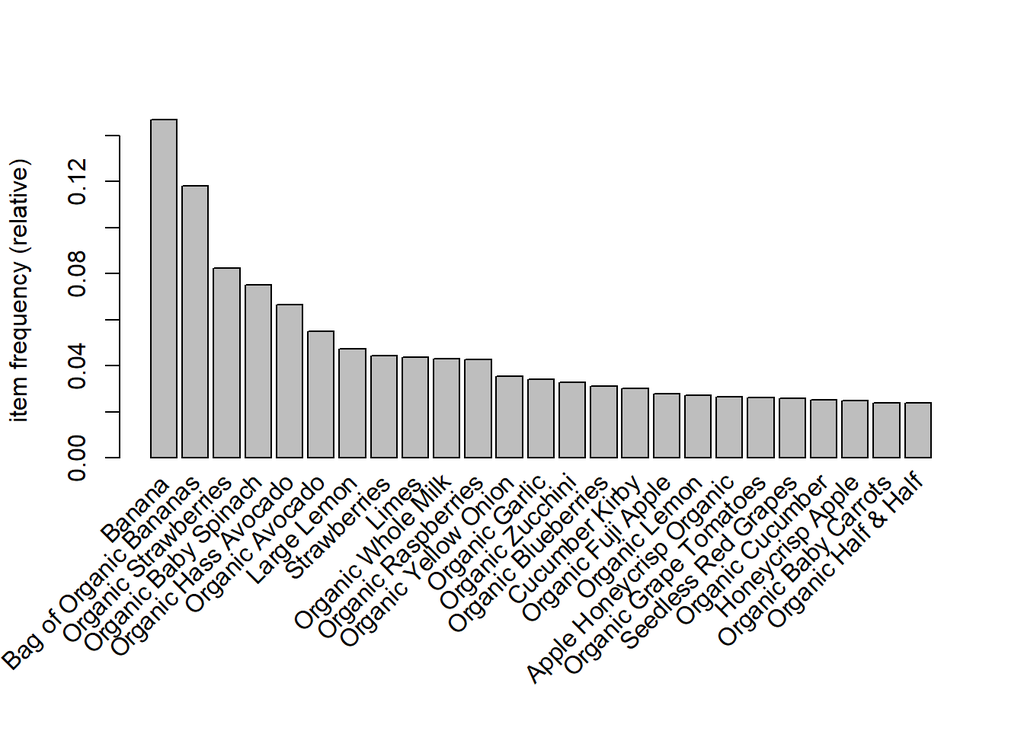

```r
itemFrequencyPlot(instacartOrders, topN = 25)
```

My objective is to use the Apriori algorithm to generate rules that help discover some actionable patterns.

```r
instacartRules <- apriori(instacartOrders, parameter = list(support = 0.006, confidence = 0.25, minlen = 2))
```

```r
length(instacartRules@quality$count)
```

```
## [1] 14
```

```r
inspect(sort(instacartRules, by = "lift"))
```

```
##      lhs                                       rhs                          support confidence     lift count
## [1]  {Organic Large Extra Fancy Fuji Apple} => {Bag of Organic Bananas} 0.007267470  0.3108362 2.633546 23364
## [2]  {Organic Fuji Apple}                   => {Banana}                 0.010558112  0.3786929 2.576259 33943
## [3]  {Organic Raspberries}                  => {Bag of Organic Bananas} 0.012598628  0.2955194 2.503775 40503
## [4]  {Organic Hass Avocado}                 => {Bag of Organic Bananas} 0.019391429  0.2918805 2.472945 62341
## [5]  {Honeycrisp Apple}                     => {Banana}                 0.008836427  0.3561283 2.422752 28408
## [6]  {Apple Honeycrisp Organic}             => {Bag of Organic Bananas} 0.007370740  0.2787109 2.361366 23696
## [7]  {Organic Cucumber}                     => {Bag of Organic Bananas} 0.006698241  0.2678625 2.269453 21534
## [8]  {Cucumber Kirby}                       => {Banana}                 0.009983906  0.3298258 2.243815 32097
## [9]  {Organic Lemon}                        => {Bag of Organic Bananas} 0.006962326  0.2550886 2.161227 22383
## [10] {Organic Avocado}                      => {Banana}                 0.016608738  0.3019823 2.054395 53395
## [11] {Seedless Red Grapes}                  => {Banana}                 0.007650067  0.2974277 2.023410 24594
## [12] {Yellow Onions}                        => {Banana}                 0.006584395  0.2893108 1.968190 21168
## [13] {Strawberries}                         => {Banana}                 0.012825386  0.2884345 1.962229 41232
## [14] {Large Lemon}                          => {Banana}                 0.012715895  0.2677899 1.821783 40880
```

These rules seem like another way of looking at the item frequency plot. Bananas are found in many orders. Additionally, many other frequent items like apples and avocadoes are found in the same order. These rules aren’t actionable because many people who order produce tend to order these items together.

### Transforming the data

If each item in the dataset also indicates which department it belongs to, then rules can be formulated such as: **“When an order contains a product from Department X, what is an item from Department Y that is also likely to be purchased?”** This could be used to promote certain items at checkout or to build a recommendation system which suggests items frequently bought together.

Here is the list of departments:

```r
departments <- read.csv('departments.csv', sep = ",", stringsAsFactors = FALSE)
data.frame('Department'=departments$department)
```

```
##         Department
## 1           frozen
## 2            other
## 3           bakery
## 4          produce
## 5          alcohol
## 6    international
## 7        beverages
## 8             pets
## 9  dry goods pasta
## 10            bulk
## 11   personal care
## 12    meat seafood
## 13          pantry
## 14       breakfast
## 15    canned goods
## 16      dairy eggs
## 17       household
## 18          babies
## 19          snacks
## 20            deli
## 21         missing
```

In order to query for products and departments, product names can be transformed into `<product name> - <department name>`:

```r
merged <- merge(x = instacartorders, y = products, by = "product_id", all.x = TRUE)
merged <- merge(x = merged, y = departments, by = "department_id", all.x = TRUE)
merged$product_name <- paste(merged$product_name, merged$department, sep = " - ")
write.csv(merged,"order_product__prior_combined.csv", row.names = FALSE)
```

Loading the dataset:

```r
instacartOrders <- read.transactions('order_product__prior_combined.csv', format = 'single', header = TRUE, sep = ",", cols = c(3,6))
```

```r
inspect(instacartOrders[3])
```

```
##     items                                                                                                  transactionID
## [1] {Cacao Sweet Raw Chocolate Nibs - pantry,
##      Jazz Apple - produce,
##      No. 01 Organic Vegan Cold Pressed Juice Kale Spinach Romaine Celery Cucumber Apple Lemon - beverages,
##      Organic Baby Kale Mix - produce,
##      Organic Unsweetened Almond Milk - dairy eggs,
##      Pitted Dates - snacks,
##      Whole Chia Seeds - snacks}                                                                                     1000
```

The items are now composed of a product name and a department name. To generate some new rules, item labels for the products in various departments will be useful:

```r
alcoholLabels <- grep("alcohol$", itemLabels(instacartOrders), value = TRUE)
beverageLabels <-  grep("beverages$", itemLabels(instacartOrders), value = TRUE)
cannedGoodLabels <- grep("canned goods$", itemLabels(instacartOrders), value = TRUE)
produceLabels <- grep("produce$", itemLabels(instacartOrders), value = TRUE)
```

Now that item labels for various deparments are available, a rule can be generated that specifically targets a department. For example, there was a lot of support in the dataset for items in the produce department, but suppose information about all other departments is desired. Which are the most frequent items purchased that are not produce?

```r
nonProduceRules <- apriori(instacartOrders, parameter = list(support = 0.001, target = 'frequent'), appearance = list(none = produceLabels))
```

```r
inspect(sort(nonProduceRules, by = "support")[1:10])
```

```
##      items                                          support    count
## [1]  {Organic Whole Milk - dairy eggs}              0.04289593 137905
## [2]  {Organic Half & Half - dairy eggs}             0.02375210  76360
## [3]  {Sparkling Water Grapefruit - beverages}       0.02360466  75886
## [4]  {Original Hummus - deli}                       0.02218252  71314
## [5]  {Half & Half - dairy eggs}                     0.02153024  69217
## [6]  {100% Whole Wheat Bread - bakery}              0.01891707  60816
## [7]  {Organic Whole String Cheese - dairy eggs}     0.01856247  59676
## [8]  {Organic Unsweetened Almond Milk - dairy eggs} 0.01800848  57895
## [9]  {Spring Water - beverages}                     0.01744610  56087
## [10] {Blueberries - frozen}                         0.01740224  55946
```

Unsurprisingly, it’s milk (and bread)! How about the most frequent in alcohol? Or canned goods?

```r
alcoholRules <- apriori(instacartOrders, parameter = list(support = 0.001, target = 'frequent'), appearance = list(items = alcoholLabels))
```

```r
inspect(sort(alcoholRules, by = "support")[1:8])
```

```
##     items                          support     count
## [1] {Sauvignon Blanc - alcohol}    0.002564953 8246
## [2] {Chardonnay - alcohol}         0.001913916 6153
## [3] {Cabernet Sauvignon - alcohol} 0.001902096 6115
## [4] {Beer - alcohol}               0.001817801 5844
## [5] {Vodka - alcohol}              0.001703022 5475
## [6] {India Pale Ale - alcohol}     0.001320425 4245
## [7] {Pinot Noir - alcohol}         0.001237062 3977
## [8] {Pinot Grigio - alcohol}       0.001006260 3235
```

```r
cannedGoodRules <- apriori(instacartOrders, parameter = list(support = 0.001, target = 'frequent'), appearance = list(items = cannedGoodLabels))
```

```r
inspect(sort(cannedGoodRules, by = "support")[1:10])
```

```
##      items                                             support     count
## [1]  {Organic Black Beans - canned goods}              0.011820370 38001
## [2]  {Organic Garbanzo Beans - canned goods}           0.009348733 30055
## [3]  {No Salt Added Black Beans - canned goods}        0.008685877 27924
## [4]  {Organic Diced Tomatoes - canned goods}           0.006842259 21997
## [5]  {Organic Low Sodium Chicken Broth - canned goods} 0.005510636 17716
## [6]  {Organic Tomato Paste - canned goods}             0.005483574 17629
## [7]  {Organic AppleApple - canned goods}               0.005016993 16129
## [8]  {Diced Tomatoes - canned goods}                   0.004308723 13852
## [9]  {Organic Tomato Sauce - canned goods}             0.004229404 13597
## [10] {Black Beans - canned goods}                      0.004207008 13525
```

From the previous examples, we see that organic black beans, and black beans more generally, have hight support in the dataset. We can create rules having only canned goods on the left hand side and items from other departments on the right hand side in order to determine if there are any actionable patterns.

```r
# Canned goods on the left hand side, all other items except produce on the right hand side
noCannedProduceLabels <- setdiff(setdiff(itemLabels(instacartOrders), cannedGoodLabels), produceLabels)
cannedRules <- apriori(instacartOrders, parameter = list(support = 1e-5, confidence = 0.05, target = "rules", minlen=2), appearance = list(lhs=cannedGoodLabels, rhs=noCannedProduceLabels))
```

Suppose canned goods are being purchased at much higher frequency than usual. This includes the most frequent of canned goods like black beans. An actionable pattern could be to determine which items from other departments have the highest likelihood of being purchased together with black beans in order to monitor their stock in case supply chain disruptions are anticipated:

```r
blackBeanRules <- subset(cannedRules, lhs %in% grep("Black Beans", cannedGoodLabels, value = TRUE))
blackBeanRulesDf <- DATAFRAME(sort(subset(blackBeanRules), by = 'confidence'))
blackBeanRulesDf[1:10,c("RHS", "support", "confidence", "lift", "count")]
```

```
##                                                     RHS      support confidence
## 867                      {Ground Turkey - meat seafood} 1.182006e-05  0.7450980
## 865       {Traditional Italian Sauce - dry goods pasta} 1.057584e-05  0.6666667
## 866                      {Ground Turkey - meat seafood} 1.368638e-05  0.6027397
## 864       {Traditional Italian Sauce - dry goods pasta} 1.244217e-05  0.5479452
## 858                    {Premium Firm Tofu - dairy eggs} 1.026479e-05  0.4520548
## 863                      {Ground Turkey - meat seafood} 1.399744e-05  0.4500000
## 862       {Traditional Italian Sauce - dry goods pasta} 1.213111e-05  0.3900000
## 857                    {Premium Firm Tofu - dairy eggs} 1.057584e-05  0.3400000
## 290                  {Fresh CA Grown Eggs - dairy eggs} 4.759129e-05  0.2084469
## 1351 {Boneless Skinless Chicken Breasts - meat seafood} 4.479180e-05  0.1716329
##            lift count
## 867   671.73200    38
## 865   772.06388    34
## 866   543.39099    44
## 864   634.57305    40
## 858  3166.22921    33
## 863   405.69077    45
## 862   451.65737    39
## 857  2381.38815    34
## 290    65.31485   153
## 1351   10.97389   144
```

Customers who purchase black beans are also likely to purchase ground turkey, pasta sauce, tofu and eggs. The lift values for these items is also very large, indicating that the rule is strong and not just due to chance. If a large spike in canned good/black bean purchases occurs, it may be useful to monitor the stock levels of these items since there is a high degree of confidence in them appearing together.

Similarly, `blackBeanRules` can also be used to recommend beverages to customers with black beans in their cart. I can use **lift** to determine those beverages where black beans is a strong predictor for being purchased:

```r
inspect(sort(subset(blackBeanRules, rhs %in% beverageLabels), by = 'lift')[1:10])
```

```
##      lhs                                                        rhs                                                     support confidence        lift count
## [1]  {Organic Black Beans - canned goods,
##       Organic Chicken Bone Broth - canned goods}             => {Honest T Pomegranate Red Herbal Tea - beverages}  1.026479e-05 0.14732143 1152.359685    33
## [2]  {Organic Black Beans - canned goods,
##       Organic Chicken Bone Broth - canned goods}             => {Black Forest Berry Caffeine-Free Tea - beverages} 1.026479e-05 0.14732143  374.403028    33
## [3]  {Organic Black Beans - canned goods,
##       Organic Chicken Bone Broth - canned goods}             => {Organic Lori's Lemon Tea - beverages}             1.026479e-05 0.14732143  290.564313    33
## [4]  {Organic Black Beans - canned goods,
##       Organic Chicken Bone Broth - canned goods}             => {Moroccan Mint Green Tea - beverages}              1.026479e-05 0.14732143  151.655405    33
## [5]  {Organic Black Beans - canned goods,
##       Organic Diced Fire Roasted Tomatoes - canned goods}    => {Italian Sparkling Mineral Water - beverages}      1.026479e-05 0.11578947   12.032471    33
## [6]  {Organic Black Beans - canned goods,
##       Vegetarian Organic Golden Corn - canned goods}         => {Sparkling Water Grapefruit - beverages}           1.088690e-05 0.09020619    3.821542    35
## [7]  {Organic AppleApple - canned goods,
##       Organic Black Beans - canned goods}                    => {Sparkling Water Grapefruit - beverages}           1.275322e-05 0.08436214    3.573962    41
## [8]  {Organic Refried Vegetarian Black Beans - canned goods} => {Spring Water - beverages}                         1.368638e-05 0.05104408    2.925817    44
## [9]  {No Salt Added Black Beans - canned goods,
##       Organic Low Sodium Chicken Broth - canned goods}       => {Sparkling Water Grapefruit - beverages}           1.617482e-05 0.06197855    2.625691    52
## [10] {No Salt Added Black Beans - canned goods,
##       Organic Tomato Sauce - canned goods}                   => {Sparkling Water Grapefruit - beverages}           1.213111e-05 0.05972435    2.530193    39
```

From these rules, an actionable pattern could be to recommend customers about different teas at checkout.